# Growth Hormone Time to Access and Outcomes: Part 2

Authors

Affiliation

Ryan Moore

VUMC Department of Biostatistics

Leena Choi

Published

Last Updated on 12 September 2024

# Project Overview

## Background

- Growth hormone products for pediatric patients can be costly and difficult to obtain.
- Patients face many barriers in obtaining these medications such as high out-of-pocket costs and delays in medication acquisition due to insurance authorization
- Access to these medications may be limited due to the complex process from the physician prescribing to delivery of the medications.
- Identifying predictors of overall medication access and time to medication initiation may improve the speed in which patients are able to initiate treatment and therefore improve growth and overall health outcomes.

## Outcome

*Primary outcome:* Determine whether time to growth hormone approval is associated with the following predictors

- Diagnosis
- Type of payer
- Medication
- Additional testing required
- Need for outside medical records

*Secondary outcome:*

Evaluate whether time to therapy initiation impacts patient growth

Evaluate whether time to therapy initiation from decision to treat (measured as number of days between treatment decision and hGh initiation) predicts patient growth

## Methods

- Single center, retrospective review of electronic medical records of patients starting treatment with growth hormone at the Vanderbilt Pediatric Endocrinology Clinic between January 1, 2018, and December 31, 2019
- Data are summarized using descriptive statistics.
- Patient growth is estimated using z scores of height by age (and sex) using the zscorer or anthro packages and WHO growth standards/references or CDC growth standards. For patients 0 to 5 years of age, the WHO growth standards are used (https://iris.who.int/handle/10665/43413). For 5 to 24 years, the WHO growth reference is used. (https://www.ncbi.nlm.nih.gov/pmc/articles/PMC2636412/pdf/07-043497.pdf/). For patients 2 to 20 years of age the CDC growth standards are used. The hfa z scores of the CDC and WHO standards are compared. A random effect model is fit to predict z score height-for-age at 1 year after decision to treat for each individual. The growth change is then calculated by subtracted the predicted z-score hfa at 1 year post-dtt from the baseline z score hfa.

## Exclusions

- Patients with missing exclusion critiera were recoded to “None of the above”

| **Characteristic** | **N** | **N = 641**<sup>1</sup> |
| --- | --- | --- |
| Exclusion | 641 |  |
| Change in hGH due to insurance change |  | 11 (1.7%) |
| Decision to treat rescinded prior to prescription approval |  | 4 (0.6%) |
| hGH renewal |  | 193 (30%) |
| None of the above |  | 374 (58%) |
| Other |  | 30 (4.7%) |
| Patient chose to pay out of pocket initially (rather than obtaining insurance approval) |  | 28 (4.4%) |
| Patient with Adult Growth Hormone Deficiency |  | 1 (0.2%) |

<sup>1</sup> n (%)

# Descriptive Statistics

## Patient Characteristics

| **Characteristic** | **N** | **N = 374**<sup>1</sup> |
| --- | --- | --- |
| Age | 374 | 11.2 (8.1, 13.3) |
| Sex | 374 |  |
| Female |  | 126 (34%) |
| Male |  | 248 (66%) |
| Ethnicity | 373 |  |
| Not Hispanic, Latino/a, or Spanish origin |  | 158 (42%) |
| Unknown |  | 166 (45%) |
| Decline to Answer |  | 11 (2.9%) |
| Mexican, Mexican American, or Chicano/a |  | 5 (1.3%) |
| Cuban |  | 1 (0.3%) |
| Other Hispanic, Latino/a, or Spanish origin |  | 32 (8.6%) |
| Missing |  | 1 |
| Race | 374 |  |
| Black |  | 20 (5.3%) |
| Other |  | 29 (7.8%) |
| Unknown |  | 24 (6.4%) |
| White |  | 301 (80%) |
| Language | 374 |  |
| English |  | 353 (94%) |
| Non-English |  | 21 (5.6%) |
| Baseline height Z-score CDC | 359 | -2.5 (-3.0, -2.0) |
| Missing |  | 15 |
| Baseline height Z-score WHO | 374 | -2.5 (-3.0, -2.0) |
| Basesline height Z-score WHO and CDC | 374 | -2.5 (-3.0, -2.0) |
| Baseline Height | 374 | 128.4 (113.6, 141.2) |
| Diagnosis | 374 |  |
| Chronic kidney disease |  | 5 (1.3%) |
| Growth hormone deficiency |  | 185 (49%) |
| Idiopathic short stature |  | 113 (30%) |
| Noonan Syndrome |  | 1 (0.3%) |
| Panhypopituitarism |  | 7 (1.9%) |
| Prader-Willi syndrome |  | 11 (2.9%) |
| Small for Gestational age |  | 35 (9.4%) |
| Turner's syndrome |  | 17 (4.5%) |
| Insurance Primary | 374 |  |
| Medicaid |  | 117 (31%) |
| Tricare |  | 12 (3.2%) |
| Commercial |  | 245 (66%) |
| Insurance Secondary | 374 |  |
| Medicaid |  | 11 (2.9%) |
| Tricare |  | 1 (0.3%) |
| Commercial |  | 10 (2.7%) |
| None |  | 346 (93%) |
| Other |  | 6 (1.6%) |
| Insurance Tertiary | 374 |  |
| Medicaid |  | 2 (0.5%) |
| Commercial |  | 8 (2.1%) |
| None |  | 359 (96%) |
| Other |  | 5 (1.3%) |
| Testing | 374 |  |
| No test |  | 335 (90%) |
| Patient tested |  | 39 (10%) |
| VSP Patient | 374 |  |
| No |  | 181 (48%) |
| Yes |  | 193 (52%) |

<sup>1</sup> Median (IQR); n (%)

## Height

#### Table

##### Summary

| **Characteristic** | **N** | **N = 374**<sup>1</sup> |
| --- | --- | --- |
| Baseline Height | 374 | 128.4 (113.6, 141.2) |
| Basesline height Z-score WHO and CDC | 374 | -2.5 (-3.0, -2.0) |
| Follow-up time for height measurements (yr) | 374 | 2.9 (2.4, 3.6) |

<sup>1</sup> Median (IQR)

#### Visualizations

##### Height over time

**Height (cm)**

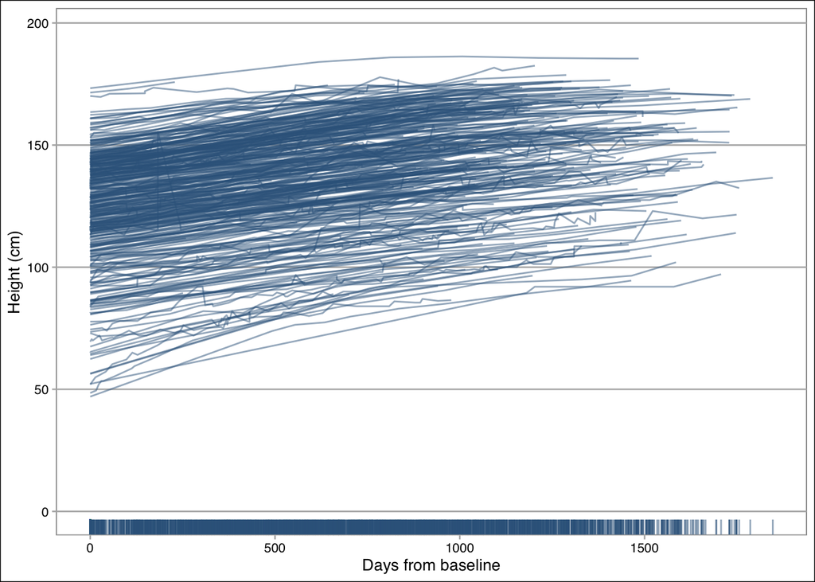

**Height (Height for age adjusted Z-score)**

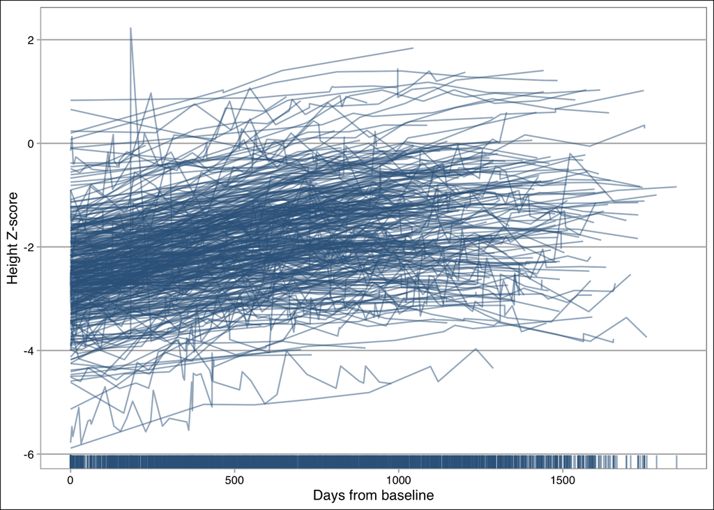

## Medication data

| **Characteristic** | **N** | **N = 374**<sup>1</sup> |
| --- | --- | --- |
| Medication | 374 |  |
| Norditropin |  | 111 (30%) |
| Nutropin |  | 30 (8.0%) |
| Genotropin |  | 123 (33%) |
| Humatrope |  | 77 (21%) |
| Omnitrope |  | 24 (6.4%) |
| Zomacton |  | 9 (2.4%) |
| Time to approval from decision to treat | 371 | 10.0 (4.0, 37.5) |
| Missing |  | 3 |
| Time to med access from decision to treat | 253 | 3.0 (1.0, 6.0) |
| Missing |  | 121 |
| Time to appeal from decision to treat | 33 | 42.0 (15.0, 62.0) |
| Missing |  | 341 |
| Interim meds started | 367 |  |
| Yes |  | 25 (6.8%) |
| No |  | 342 (93%) |
| Missing |  | 7 |
| Delay not from insurance | 372 |  |
| No |  | 321 (86%) |
| Yes |  | 51 (14%) |
| Missing |  | 2 |
| Testing | 374 |  |
| No test |  | 335 (90%) |
| Patient tested |  | 39 (10%) |
| Outside records | 374 |  |
| No |  | 364 (97%) |
| Yes |  | 10 (2.7%) |
| PA completed for multiple insurance | 374 |  |
| No |  | 352 (94%) |
| Yes |  | 22 (5.9%) |
| Change insurance | 21 |  |
| No |  | 17 (81%) |
| Yes |  | 4 (19%) |
| Missing |  | 353 |
| Number of PA | 374 |  |
| none |  | 11 (2.9%) |
| 1 |  | 288 (77%) |
| 2 |  | 67 (18%) |
| 3 |  | 7 (1.9%) |
| >3 |  | 1 (0.3%) |
| PA denial | 111 |  |
| Off-label use |  | 0 (0%) |
| Did not meet criteria or required formulary alternative |  | 50 (45%) |
| Non preferred agent |  | 2 (1.8%) |
| Diagnosis not covered |  | 53 (48%) |
| Other |  | 6 (5.4%) |
| Missing |  | 263 |
| pa_denial_other | 6 |  |
| diagnosis of ISS not considered medically necessary |  | 1 (17%) |
| Gh excluded from plan |  | 2 (33%) |
| GH excluded from plan |  | 1 (17%) |
| GH not covered under plan |  | 1 (17%) |
| TennCare only pays for drug if they've tried other drugs that cost less |  | 1 (17%) |
| Missing |  | 368 |
| Appeal number | 90 |  |
| 1 |  | 51 (57%) |
| 2 |  | 28 (31%) |
| 3 |  | 11 (12%) |
| Missing |  | 284 |
| Assistance | 320 |  |
| Copay card |  | 71 (22%) |
| MAP |  | 3 (0.9%) |
| Other |  | 1 (0.3%) |
| None |  | 138 (43%) |
| Uknown |  | 107 (33%) |
| Missing |  | 54 |

<sup>1</sup> n (%); Median (IQR)

## Time to insurance approval

```
Time differences in days
  0%  25%  50%  75% 100%
   1   46   94  155  215
```

| **Characteristic** | **N = 374**<sup>1</sup> |
| --- | --- |
| Prior Authorization Approved |  |
| N | 264 |
| Median (IQR) | 3 (1, 6) |
| Range | 0, 421 |
| Unknown | 110 |
| Appeal Approved |  |
| N | 56 |
| Median (IQR) | 34 (22, 68) |
| Range | 3, 1,121 |
| Unknown | 318 |
| PAP Approved |  |
| N | 48 |
| Median (IQR) | 84 (59, 122) |
| Range | 7, 430 |
| Unknown | 326 |
| Cash Pay Decided |  |
| 1 | 1 (14%) |
| 13 | 1 (14%) |
| 79 | 1 (14%) |
| 94 | 1 (14%) |
| 118 | 1 (14%) |
| 192 | 1 (14%) |
| 215 | 1 (14%) |
| Unknown | 367 |

<sup>1</sup> n (%)

# Analysis

## Modeling time to appeal or PAP approval

### Outcome

| **Characteristic** | **N** | **N = 374**<sup>1</sup> |
| --- | --- | --- |
| Time to approval (days) | 374 | 5.0 (1.0, 32.0) |
| Type of approval | 374 |  |
| Appeal approval time |  | 55 (15%) |
| Bi initiation |  | 13 (3.5%) |
| Cash pay |  | 7 (1.9%) |
| PA approval time |  | 251 (67%) |
| PAP approval time |  | 48 (13%) |

<sup>1</sup> Median (IQR); n (%)

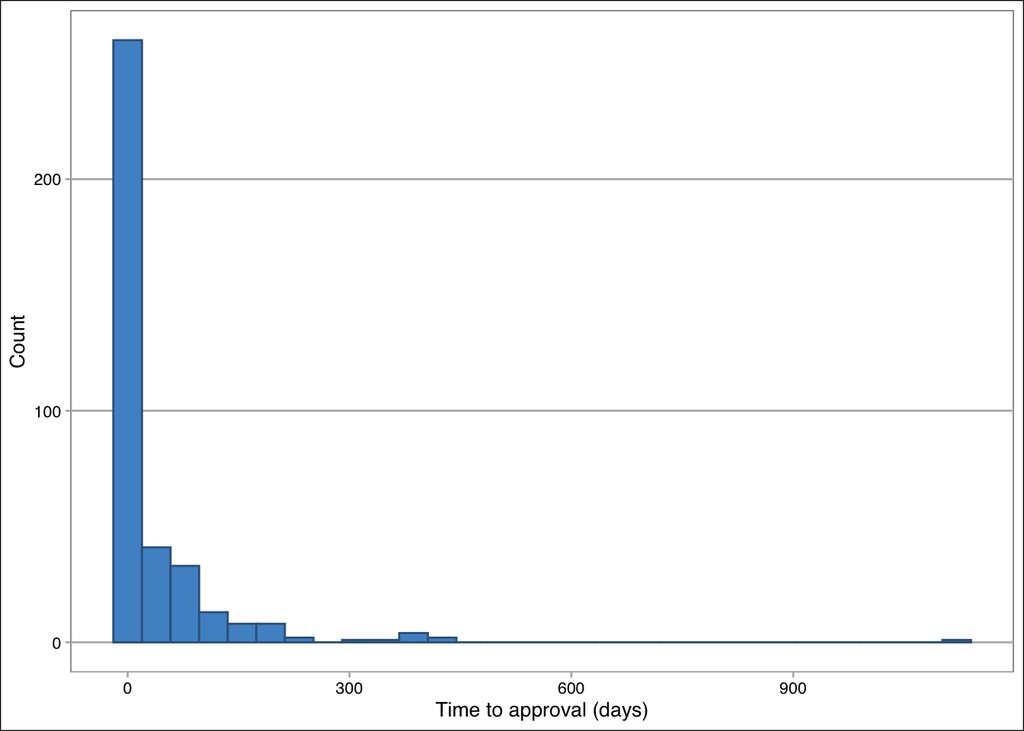

### Data exploration visualizations

#### Diagnosis

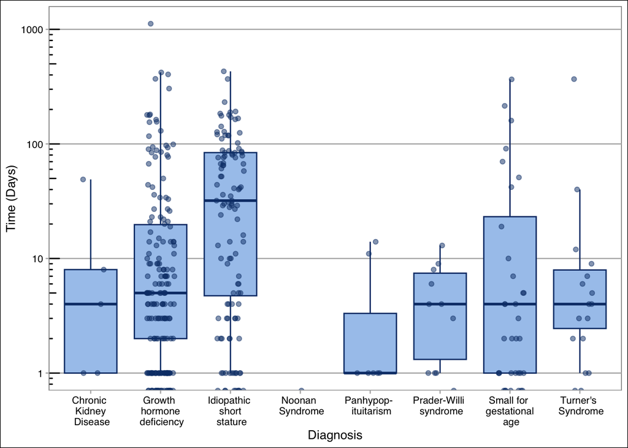

#### Testing

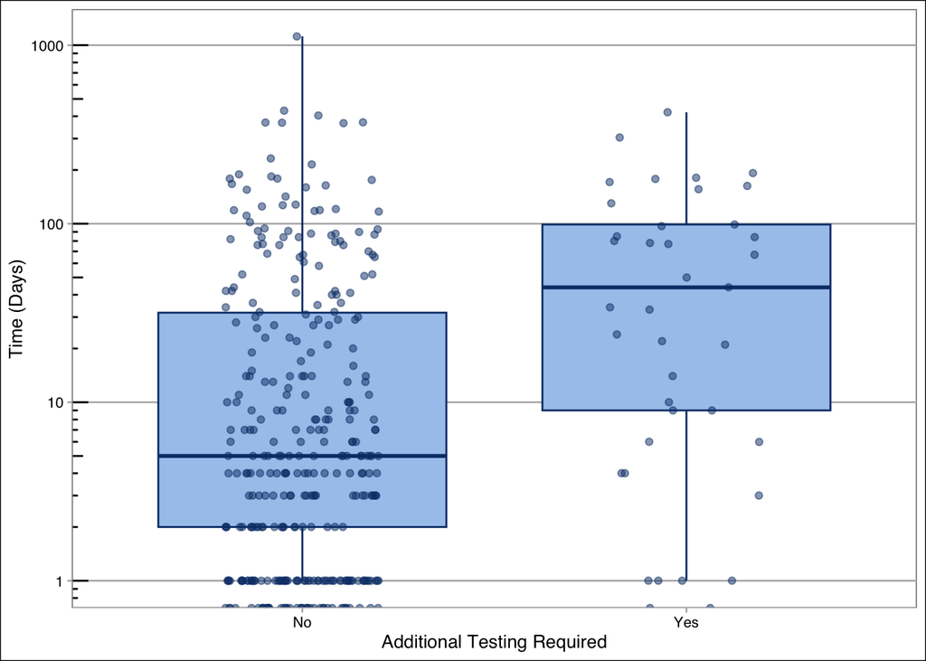

### CoxPH Analysis

```
Call:
coxph(formula = S ~ age + diagnosis_cat + insurance_prim + vsp_patient +
    testing, data = moddat)

  n= 374, number of events= 367

                                            coef exp(coef)  se(coef)      z
age                                     0.007299  1.007326  0.014507  0.503
diagnosis_catGrowth hormone deficiency  0.647982  1.911680  0.131795  4.917
diagnosis_catTurner's syndrome          0.686005  1.985767  0.270598  2.535
diagnosis_catSmall for Gestational age  0.470778  1.601240  0.217674  2.163
diagnosis_catPrader-Willi syndrome      1.043579  2.839361  0.343887  3.035
diagnosis_catPanhypopituitarism         0.972065  2.643397  0.403622  2.408
diagnosis_catNoonan Syndrome            3.217320 24.961143  1.024771  3.140
diagnosis_catChronic kidney disease     0.314772  1.369947  0.468542  0.672
insurance_primMedicaid                  0.327585  1.387613  0.120217  2.725
insurance_primTricare                   0.358984  1.431873  0.302285  1.188
vsp_patientYes                          0.411643  1.509295  0.118114  3.485
testingPatient tested                  -0.913522  0.401109  0.184960 -4.939
                                       Pr(>|z|)
age                                    0.614845
diagnosis_catGrowth hormone deficiency 8.81e-07 ***
diagnosis_catTurner's syndrome         0.011240 *
diagnosis_catSmall for Gestational age 0.030559 *
diagnosis_catPrader-Willi syndrome     0.002408 **
diagnosis_catPanhypopituitarism        0.016025 *
diagnosis_catNoonan Syndrome           0.001692 **
diagnosis_catChronic kidney disease    0.501704
insurance_primMedicaid                 0.006431 **
insurance_primTricare                  0.235004
vsp_patientYes                         0.000492 ***
testingPatient tested                  7.85e-07 ***
---
Signif. codes:  0 '***' 0.001 '**' 0.01 '*' 0.05 '.' 0.1 ' ' 1

                                       exp(coef) exp(-coef) lower .95 upper .95
age                                       1.0073    0.99273    0.9791    1.0364
diagnosis_catGrowth hormone deficiency    1.9117    0.52310    1.4765    2.4751
diagnosis_catTurner's syndrome            1.9858    0.50358    1.1684    3.3749
diagnosis_catSmall for Gestational age    1.6012    0.62452    1.0451    2.4532
diagnosis_catPrader-Willi syndrome        2.8394    0.35219    1.4471    5.5711
diagnosis_catPanhypopituitarism           2.6434    0.37830    1.1984    5.8308
diagnosis_catNoonan Syndrome             24.9611    0.04006    3.3495  186.0163
diagnosis_catChronic kidney disease       1.3699    0.72996    0.5469    3.4318
insurance_primMedicaid                    1.3876    0.72066    1.0963    1.7563
insurance_primTricare                     1.4319    0.69839    0.7918    2.5895
vsp_patientYes                            1.5093    0.66256    1.1974    1.9024
testingPatient tested                     0.4011    2.49309    0.2791    0.5764

Concordance= 0.663  (se = 0.016 )
Likelihood ratio test= 80.21  on 12 df,   p=4e-12
Wald test            = 80.48  on 12 df,   p=3e-12
Score (logrank) test = 89.48  on 12 df,   p=6e-14
```

```
Analysis of Deviance Table
 Cox model: response is S
Terms added sequentially (first to last)

                loglik   Chisq Df Pr(>|Chi|)
NULL           -1818.9
age            -1817.7  2.4363  1   0.118556
diagnosis_cat  -1802.4 30.6016  7  7.362e-05 ***
insurance_prim -1797.3 10.2578  2   0.005923 **
vsp_patient    -1793.2  8.0468  1   0.004559 **
testing        -1778.8 28.8686  1  7.746e-08 ***
---
Signif. codes:  0 '***' 0.001 '**' 0.01 '*' 0.05 '.' 0.1 ' ' 1
```

## Modeling height

### Linear regression Model

**Linear Regression Model**

```
ols(formula = Predicted_Height_1yr_DTT ~ Predicted_Height_at_DTT +
    Race + I(Time_to_Approval/365.25) + Interim_Meds_Started +
    Diagnosis + Testing + VSP_Patient, data = h_mod)
```

Frequencies of Missing Values Due to Each Variable

```
Predicted_Height_1yr_DTT  Predicted_Height_at_DTT                     Race
                       0                        0                        0
        Time_to_Approval     Interim_Meds_Started                Diagnosis
                       0                        7                        0
                 Testing              VSP_Patient
                       0                        0
```

|  | Model Likelihood Ratio Test | Discrimination Indexes |
| --- | --- | --- |
| Obs 363 | LR χ<sup>2</sup> 872.19 | *R*<sup>2</sup> 0.910 |
| σ 0.2698 | d.f. 14 | *R*<sup>2</sup><sub>adj</sub> 0.906 |
| d.f. 348 | Pr(>χ<sup>2</sup>) 0.0000 | *g* 0.905 |

Residuals

```
     Min       1Q   Median       3Q      Max
-0.70942 -0.16826  0.01147  0.16071  1.24445
```

|  | β | S.E. | *t* | Pr(>\|*t*\|) |
| --- | --- | --- | --- | --- |
| Intercept | 0.1982 | 0.0492 | 4.03 | <0.0001 |
| Predicted_Height_at_DTT | 0.9058 | 0.0170 | 53.30 | <0.0001 |
| Race=Black | -0.1711 | 0.0634 | -2.70 | 0.0073 |
| Race=Other | -0.0435 | 0.0419 | -1.04 | 0.2998 |
| Time_to_Approval | 0.0052 | 0.0604 | 0.09 | 0.9317 |
| Interim_Meds_Started=Yes | -0.0278 | 0.0580 | -0.48 | 0.6318 |
| Diagnosis=Chronic kidney disease | 0.1136 | 0.1249 | 0.91 | 0.3639 |
| Diagnosis=Idiopathic short stature | -0.0971 | 0.0349 | -2.78 | 0.0057 |
| Diagnosis=Noonan Syndrome | -0.3741 | 0.2715 | -1.38 | 0.1691 |
| Diagnosis=Panhypopituitarism | -0.0209 | 0.1050 | -0.20 | 0.8426 |
| Diagnosis=Prader-Willi syndrome | 0.2411 | 0.0884 | 2.73 | 0.0067 |
| Diagnosis=Small for Gestational age | -0.1114 | 0.0512 | -2.18 | 0.0302 |
| Diagnosis=Turner's syndrome | -0.1043 | 0.0694 | -1.50 | 0.1336 |
| Testing=Patient tested | -0.0043 | 0.0484 | -0.09 | 0.9287 |
| VSP_Patient=Yes | -0.0523 | 0.0299 | -1.75 | 0.0810 |

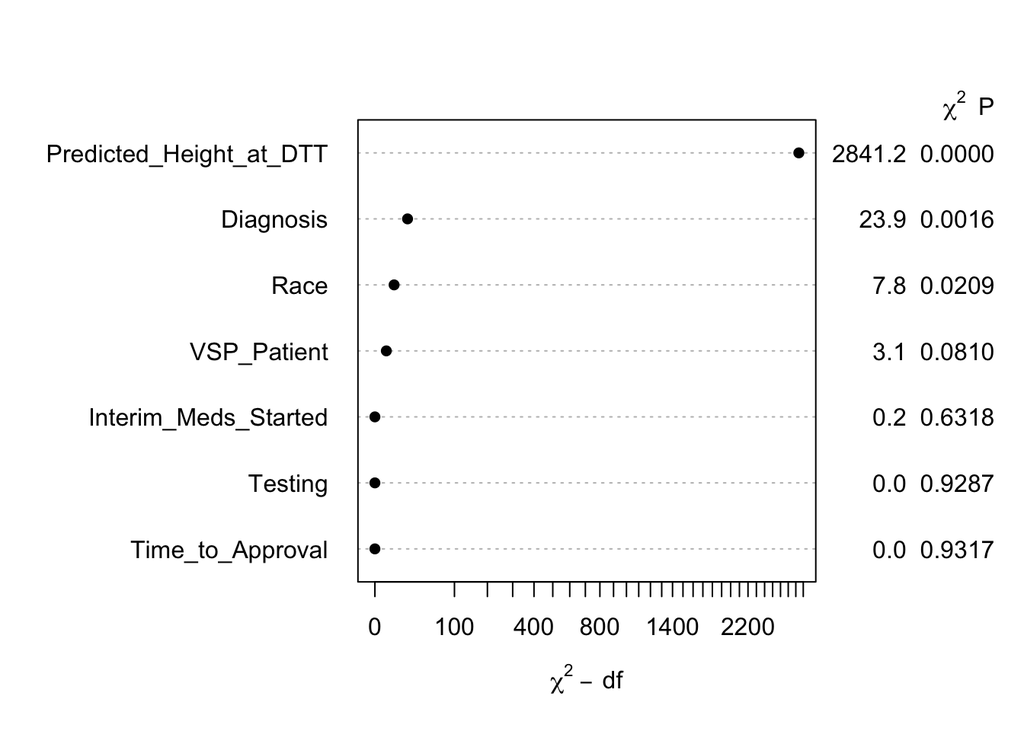

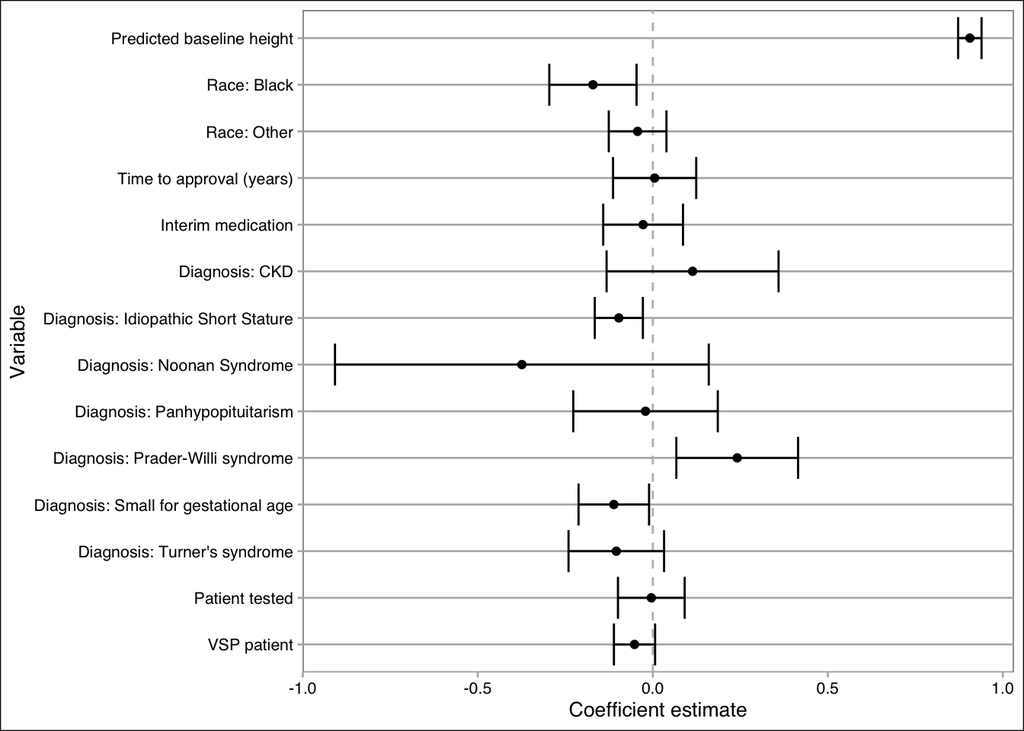